Use the dataset `Carseats` in the package `ISLR`, we seek to predict `Sales` using regression trees and related approaches, treating the response as a quantitative variable.

Use the dataset Carseats in the package ISLR, we seek to predict Sales using regression trees and related approaches, treating the response as a quantitative variable.

1. Split the data set into a training set and a test set.

```r
set.seed(1)
rs <- initial_split(Carseats, prop = 0.7)
train_set <- as_tibble(training(rs))
test_set <- as_tibble(testing(rs))
```

2. Fit a regression tree to the training set. Plot the tree, and interpret the results. What test MSE do you obtain?

```r
tree_fit <- tree(Sales~., train_set)
summary(tree_fit)
```

```
##
## Regression tree:
## tree(formula = Sales ~ ., data = train_set)
## Variables actually used in tree construction:
## [1] "ShelveLoc"   "Price"       "CompPrice"   "Income"      "Advertising"
## [6] "Age"
## Number of terminal nodes:  20
## Residual mean deviance:  2.242 = 582.8 / 260
## Distribution of residuals:
##     Min.  1st Qu.   Median     Mean  3rd Qu.     Max.
## -3.94100 -1.10900  0.05135  0.00000  1.05000  3.84700
```

```r
unique(train_set$ShelveLoc)
```

```
## [1] Bad    Good   Medium
## Levels: Bad Good Medium
```

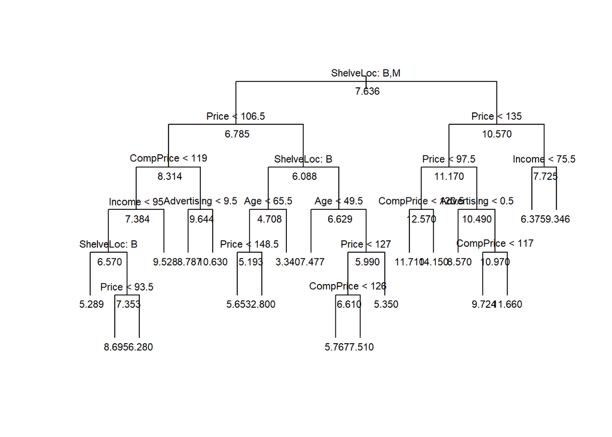

```r
plot(tree_fit, type = "uniform")
text(tree_fit, pretty = 1, all = TRUE, cex = 0.7)
```

```r
tree_pred <- predict(tree_fit, test_set, n.trees=1000)
test_mse <- mean((test_set$Sales - tree_pred)^2) # 4.510511
test_mse
```

```
## [1] 4.510511
```

3. Use cross-validation in order to determine the optimal level of tree complexity. Does pruning the tree improve the test MSE?

Pruning did not improve test MSE, but it did simplify the overall tree and the reduction in performance was not particularly large (~1).

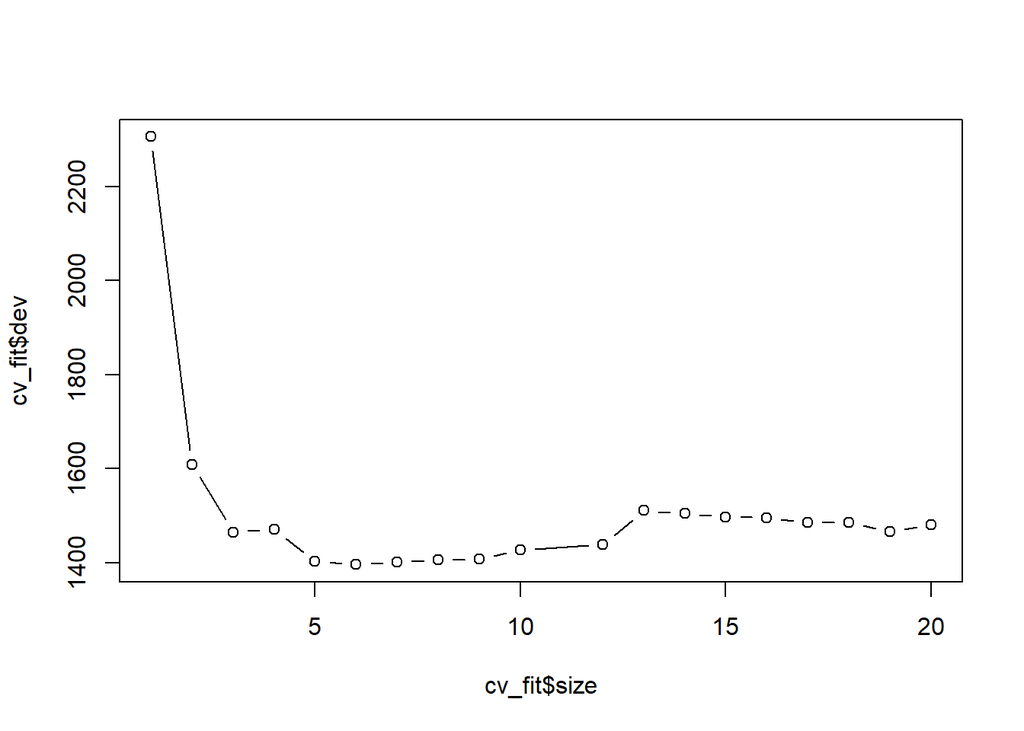

```r
cv_fit <- cv.tree(tree_fit,,prune.tree)
plot(cv_fit$size, cv_fit$dev, type = "b")
```

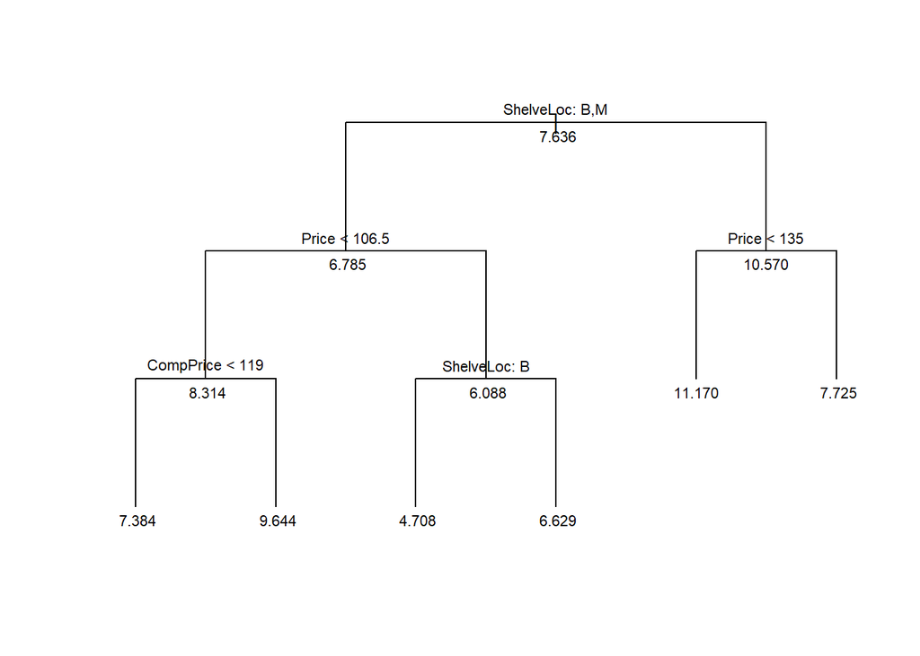

```r
bestSize<-cv_fit$size[which.min(cv_fit$dev)]

prune_fit <- prune.tree(tree_fit, best=bestSize)
plot(prune_fit, type="uniform")
text(prune_fit, pretty = 1, all = TRUE, cex = 0.7)
```

```r
tree_pred <- predict(prune_fit, test_set, n.trees=1000)
test_prune_mse <- mean((test_set$Sales - tree_pred)^2) # 4.510511
test_prune_mse # 5.653301
```

```
## [1] 5.490626
```

4. Use the MARS approach in order to analyze this data. What test MSE do you obtain?

The test MSE was 1.210921 with the MARS approach, a significant improvement from the tree and prune.tree.

```r
mars_fit <- earth(Sales~., train_set)
modelr::mse(mars_fit, test_set)
```

```
## [1] 1.210921
```

```
##  plotmo grid:    CompPrice Income Advertising Population Price ShelveLoc
##                        125   67.5           6        271   118    Medium
##  Age Education Urban  US
##   53        13   Yes Yes
```

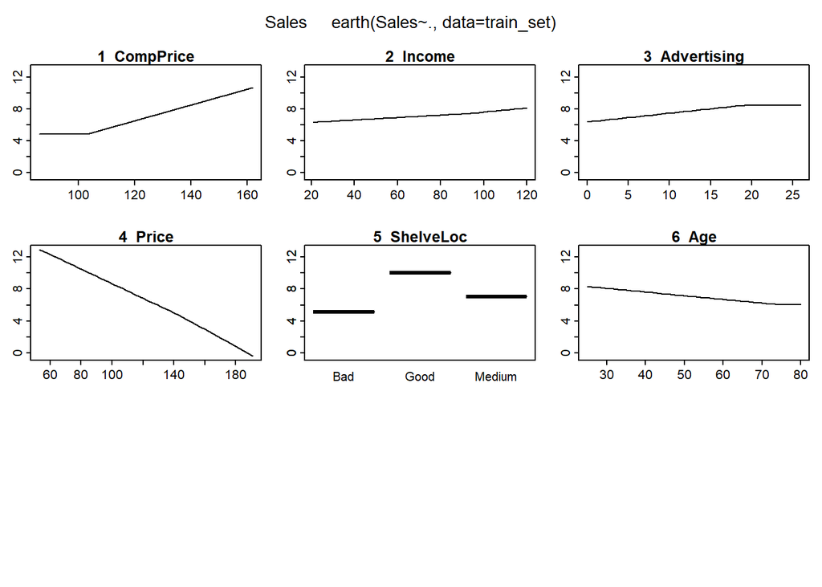

```r
plotmo(mars_fit)
```

5. Use the bagging (bootstrap) approach to analyze this data. What test MSE do you obtain? Use the importance() function to determine which variables are most important. You may need to use the `bootstraps` function in `tidymodels`.

The test MSE obtained from a bagged tree was 2.588486; improved from a pruned tree, but not better than the MARS tree. The most important variable was Price, followed by ShelveLoc then Age.

```r
set.seed (1)
#names(train_set)
bag_train=sample (1:nrow(Carseats), 200)
bag_fit=randomForest(Sales~.,data=Carseats, subset=bag_train, mtry=10, importance =TRUE)
importance(bag_fit)
```

```
##               %IncMSE IncNodePurity
## CompPrice   13.743690    128.760199
## Income       3.640159     74.882915
## Advertising 16.126838    123.784498
## Population   2.319493     62.284127
## Price       53.729997    508.091822
## ShelveLoc   43.864134    323.461715
## Age         21.009078    190.312978
## Education    2.318205     41.002285
## Urban       -1.145363      9.323406
## US           7.434434     15.172556
```

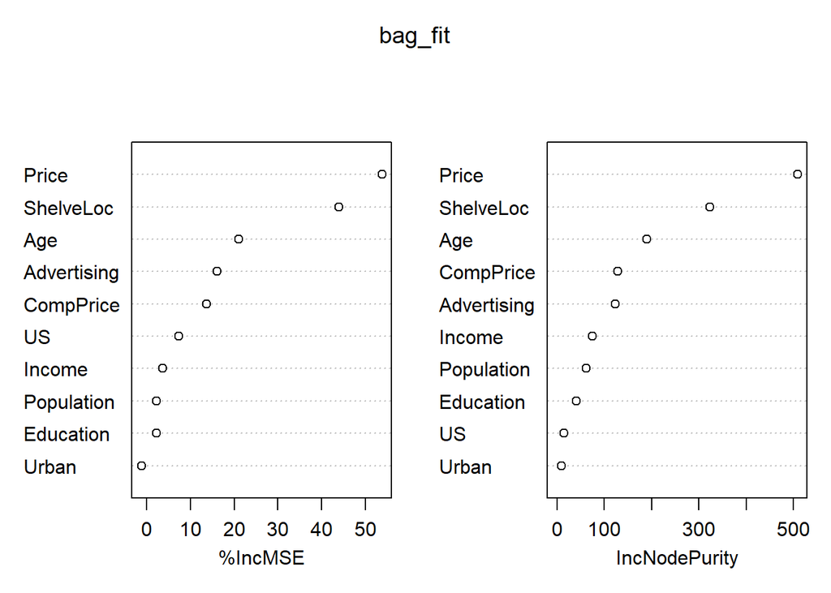

```r
varImpPlot(bag_fit)
```

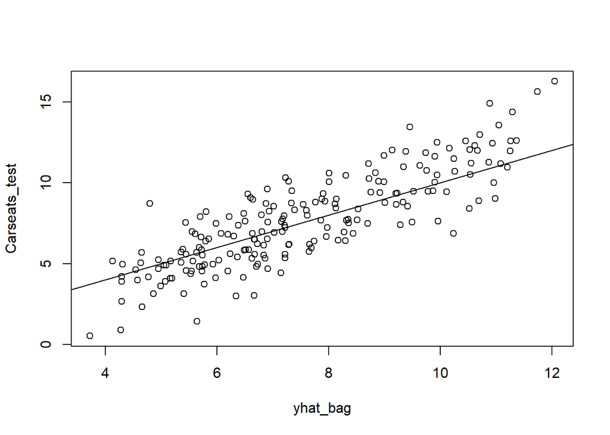

```r
Carseats_test=Carseats[-bag_train ,"Sales"]
yhat_bag = predict (bag_fit, newdata=Carseats[-bag_train,])
plot(yhat_bag, Carseats_test)
abline (0,1)
```

```r
bag_mse<-mean((yhat_bag-Carseats_test)^2) # 2.588486
```

6. Use random forests to analyze this data. What test MSE do you obtain? Use the importance() function to determine which variables are most important. Describe the effect of m, the number of variables considered at each split, on the error rate obtained.

```r
set.seed(1)
rf_fit_full <- randomForest(Sales~., train_set, mtry = 10)
rf_fit_full
```

```
##
## Call:
##  randomForest(formula = Sales ~ ., data = train_set, mtry = 10)
##                Type of random forest: regression
##                      Number of trees: 500
## No. of variables tried at each split: 10
##
##           Mean of squared residuals: 2.628228
##                     % Var explained: 67.8
```

```r
modelr::mse(rf_fit_full, test_set) # 2.619718
```

```
## [1] 2.619718
```

```r
rf_fit <- randomForest(Sales~., train_set, mtry = 10, importance = TRUE)
modelr::mse(rf_fit, test_set) # 2.669289
```

```
## [1] 2.669289
```

```r
rf_fit_sqm <- randomForest(Sales~., train_set, mtry = sqrt(10), importance = TRUE)
modelr::mse(rf_fit_sqm, test_set) # 2.931327
```

```
## [1] 2.877194
```

```r
importance(rf_fit)
```

```
##               %IncMSE IncNodePurity
## CompPrice   29.135567    239.232993
## Income      10.397550    132.974473
## Advertising 14.684072    119.774507
## Population  -1.287610     73.810961
## Price       66.460803    583.285970
## ShelveLoc   80.702014    823.758131
## Age         14.703504    186.411472
## Education    3.632187     62.800891
## Urban        1.577010      8.856149
## US           2.949621     10.482857
```

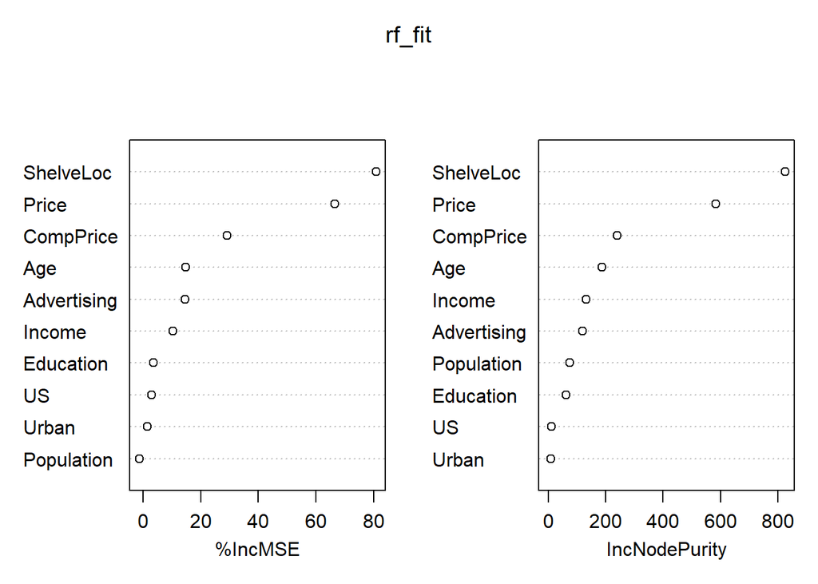

```r
varImpPlot(rf_fit) # The most important variable was ShelveLoc, followed by Price, then CompPrice.
```